# Analysis of Monetary Damage and Population Damage from wheather events: 2001 - 2011

Luis Alberto Macías Barrales

9/15/2020

## Synopsis

In the current analysis we study the monetary damage and population damage produced from weather disasters in the USA across the years 2001 to 2011. We use data from the National Oceanic and Atmospheric Administration’s (NOAA) storm database. In the first section it is presented the methods to clean and organize the data. In the second section, the analysis is performed in order to study the most harmful type of events across these years. This analysis is divided into monetary damage and population damage, both divided into the most harmful events and the most affected states. In the last setion the results are presented.

## Loading and processing the data

The data is downloaded from this link

```r
url <- "https://d396qusza40orc.cloudfront.net/repdata%2Fdata%2FStormData.csv.bz2"
download.file(url, destfile = "data_storm.csv.bz2")
storm <- read.csv("data_storm.csv", header = T, na.strings = "")
```

If we observe at the structure of the dataset, we can see that it is necessary to convert some types of data:

```r
str(storm)
```

```
## 'data.frame':    902297 obs. of  37 variables:
##  $ STATE__   : num  1 1 1 1 1 1 1 1 1 1 ...
##  $ BGN_DATE  : chr  "4/18/1950 0:00:00" "4/18/1950 0:00:00" "2/20/1951 0:00:00" "6/8/1951 0:00:00" ...
##  $ BGN_TIME  : chr  "0130" "0145" "1600" "0900" ...
##  $ TIME_ZONE : chr  "CST" "CST" "CST" "CST" ...
##  $ COUNTY    : num  97 3 57 89 43 77 9 123 125 57 ...
##  $ COUNTYNAME: chr  "MOBILE" "BALDWIN" "FAYETTE" "MADISON" ...
##  $ STATE     : chr  "AL" "AL" "AL" "AL" ...
##  $ EVTYPE    : chr  "TORNADO" "TORNADO" "TORNADO" "TORNADO" ...
##  $ BGN_RANGE : num  0 0 0 0 0 0 0 0 0 0 ...
##  $ BGN_AZI   : chr  NA NA NA NA ...
##  $ BGN_LOCATI: chr  NA NA NA NA ...
##  $ END_DATE  : chr  NA NA NA NA ...
##  $ END_TIME  : chr  NA NA NA NA ...
##  $ COUNTY_END: num  0 0 0 0 0 0 0 0 0 0 ...
```

[output cut: 23 more lines]

```r
library(dplyr)
storm$BGN_DATE <- as.Date(storm$BGN_DATE, format = "%m/%d/%Y")
storm$END_DATE <- as.Date(storm$END_DATE, format = "%m/%d/%Y")
stormdata <- select(storm, -c("BGN_RANGE", "BGN_AZI", "BGN_LOCATI" , "COUNTY_END", "COUNTYENDN", "END_RANGE", "END_AZI", "END_LOCATI", "WFO", "STATEOFFIC", "ZONENAMES", "LATITUDE", "LONGITUDE", "LATITUDE_E", "LONGITUDE_", "REMARKS", "REFNUM" ))
stormdata <- filter(stormdata, stormdata$BGN_DATE >= "2001-01-01")
```

The following step to clean the data is to fix the PROPDMG and CROPDMG columns so all values are in the same units. PROPDAMGEXP and CROPDMGEXP have values “K”, “M” and “B” which correspond to thousand, millions, billions of dollars and also have values NA or “0” that indicates that there were not damages at that event. We will set units in millions of dollars.

```r
stormdata$PROPDMGEXP <- sub("K", ".001", stormdata$PROPDMGEXP)
stormdata$PROPDMGEXP <- sub("M", "1", stormdata$PROPDMGEXP)
stormdata$PROPDMGEXP <- sub("B", "1000", stormdata$PROPDMGEXP)
stormdata$PROPDMGEXP[is.na(stormdata$PROPDMGEXP)] <- "0"
stormdata$PROPDMGEXP <- as.numeric(stormdata$PROPDMGEXP)
stormdata$PROPDMG <- stormdata$PROPDMG * stormdata$PROPDMGEXP
stormdata$CROPDMGEXP <- sub("K", ".001", stormdata$CROPDMGEXP)
stormdata$CROPDMGEXP <- sub("M", "1", stormdata$CROPDMGEXP)
stormdata$CROPDMGEXP <- sub("B", "1000", stormdata$CROPDMGEXP)
stormdata$CROPDMGEXP[is.na(stormdata$CROPDMGEXP)] <- "0"
stormdata$CROPDMGEXP <- as.numeric(stormdata$CROPDMGEXP)
stormdata$CROPDMG <- stormdata$CROPDMG * stormdata$CROPDMGEXP

stormdata <- select(stormdata, -c(PROPDMGEXP,CROPDMGEXP))
```

The last step of data cleaning, and the most challenging one, is to correct typos of types of events. According to [Storm Data Documentation](https://d396qusza40orc.cloudfront.net/repdata%2Fpeer2_doc%2Fpd01016005curr.pdf), there are 48 different types of events and in this subset of data there are 169 different types. There is one observation that is marked as others, so we first eliminate this since probably is not significant. Next, we proceed to match some event types by hand before we can use some more elegant methods.

```r
stormdata <- filter(stormdata, !(stormdata$EVTYPE=="OTHER"))

stormdata$EVTYPE <- sub("   ", "",stormdata$EVTYPE)
stormdata$EVTYPE <- sub("BRUSH FIRE", "WILDFIRE", stormdata$EVTYPE)
stormdata$EVTYPE <- sub(" WATERSPOUT", "WATERSPOUT", stormdata$EVTYPE)
stormdata$EVTYPE <- sub("BLOWING DUST", "DUST STORM", stormdata$EVTYPE)
stormdata$EVTYPE <- sub("COLD WEATHER", "COLD/WIND CHILL", stormdata$EVTYPE)
stormdata$EVTYPE <- sub("COLD WIND CHILL TEMPERATURES", "COLD/WIND CHILL", stormdata$EVTYPE)
stormdata$EVTYPE[stormdata$EVTYPE == "COLD"] <- "COLD/WIND CHILL"
stormdata$EVTYPE <- sub("COASTAL FLOODING", "COASTAL FLOOD", stormdata$EVTYPE)
stormdata$EVTYPE <- sub("COASTAL FLOODING", "COASTAL FLOOD", stormdata$EVTYPE)
stormdata$EVTYPE <- sub("CSTL FLOODING/EROSION", "COASTAL FLOOD", stormdata$EVTYPE)
stormdata$EVTYPE <- sub("RECORD HEAT", "EXCESSIVE HEAT", stormdata$EVTYPE)
stormdata$EVTYPE <- sub("RECORD COLD", "EXCESSIVE COLD/ WIND CHILL", stormdata$EVTYPE)
stormdata$EVTYPE <- sub("FOG", "DENSE FOG", stormdata$EVTYPE)
```

Next, we use “amatch” function from stringdist package to match events in stormdata data set with official events. And we eliminate entries where amatch function indicates NA.

```r
library(stringdist)
events <- c("Astronomical Low Tide", "Avalanche", "Blizzard", "Coastal Flood", "Cold/Wind Chill", "Debris Flow", "Dense Fog", "Dense Smoke", "Drought", "Dust Devil", "Dust Storm", "Excessive Heat", "Extreme Cold/Wind Chill", "Flash Flood", "Flood", "Frost/Freeze", "Funnel Cloud", "Freezing Fog", "Hail", "Heat", "Heavy Rain", "Heavy Snow", "High Surf", "High Wind", "Hurricane (Typhoon)", "Ice Storm", "Lake-Effect Snow", "Lakeshore Flood", "Lightning", "Marine Hail", "Marine High Wind", "Marine Strong Wind", "Marine Thunderstorm Wind", "Rip Current", "Seiche", "Sleet", "Storm Surge/Tide", "Strong Wind", "Thunderstorm Wind", "Tornado", "Tropical Depression", "Tropical Storm", "Tsunami", "Volcanic Ash", "Waterspout", "Wildfire", "Winter Storm", "Winter Weather")
events <- toupper(events)
stormdata$match <- amatch(stormdata$EVTYPE, events, method = "jw", maxDist = 0.3)
stormdata <- filter(stormdata, !is.na(stormdata$match))
for (i in 1:48){
            stormdata$EVTYPE[stormdata$match==i] <- events[i]
}
```

## Results

### Damage per type of event

First, we evaluate the mean of the monetary and population damage per type of event and take the ten most harmful of them

```r
storm_mean <- stormdata %>% group_by(EVTYPE) %>%
            summarise(mean_prop = mean(PROPDMG), mean_crop = mean(CROPDMG), mean_total = mean(PROPDMG+CROPDMG), mean_fat = mean(FATALITIES), mean_inj = mean(INJURIES))
top_monetary <- arrange(storm_mean[,c("EVTYPE", "mean_prop", "mean_crop", "mean_total")], desc(storm_mean$mean_total))[1:10,]
top_population <- arrange(storm_mean[,c("EVTYPE", "mean_fat", "mean_inj")], desc(storm_mean$mean_fat))[1:10,]
top_monetary
```

```
## # A tibble: 10 x 4
##    EVTYPE              mean_prop mean_crop mean_total
##    <chr>                   <dbl>     <dbl>      <dbl>
##  1 HURRICANE (TYPHOON) 544.       23.0        567.
##  2 STORM SURGE/TIDE    178.        0.00317    178.
##  3 TROPICAL STORM       11.9       0.681       12.6
##  4 FLOOD                 7.04      0.190        7.23
##  5 TSUNAMI               7.20      0.001        7.20
##  6 DROUGHT               0.437     3.46         3.89
##  7 WILDFIRE              1.46      0.0871       1.55
##  8 ICE STORM             1.49      0.00652      1.49
##  9 TORNADO               1.15      0.0138       1.17
## 10 FROST/FREEZE          0.00698   0.805        0.812
```

```r
top_population
```

```
## # A tibble: 10 x 3
##    EVTYPE                  mean_fat mean_inj
##    <chr>                      <dbl>    <dbl>
##  1 TSUNAMI                   1.65     6.45
##  2 EXCESSIVE HEAT            0.808    3.06
##  3 RIP CURRENT               0.760    0.642
##  4 AVALANCHE                 0.543    0.363
##  5 HURRICANE (TYPHOON)       0.511    9.71
##  6 HEAT                      0.324    1.72
##  7 COLD/WIND CHILL           0.175    0.0216
##  8 HIGH SURF                 0.148    0.239
##  9 EXTREME COLD/WIND CHILL   0.124    0.0207
## 10 TROPICAL STORM            0.0826   0.441
```

From these tables, we can see that in average, the event that has the more monetary impact across all USA are hurricanes/typhons, with and average of $566.92 millions of dollar per event. On the other hand, the event that has the major number of casualties in average are tsunamis, with 1.66 casualties each time.

Now, we count the total damage per type of event

```r
total_fat <- sapply(split(stormdata[,c("EVTYPE", "FATALITIES")], stormdata$EVTYPE), function(x){sum(x[,2])})
total_inj <- sapply(split(stormdata[,c("EVTYPE", "INJURIES")], stormdata$EVTYPE), function(x){sum(x[,2])})

total_prop <-  sapply(split(stormdata[,c("EVTYPE", "PROPDMG")], stormdata$EVTYPE), function(x){sum(x[,2])})
total_crop <-  sapply(split(stormdata[,c("EVTYPE", "CROPDMG")], stormdata$EVTYPE), function(x){sum(x[,2])})

stormdata$totaldmg <- stormdata$PROPDMG+stormdata$CROPDMG
total_total <-   sapply(split(stormdata[,c("EVTYPE", "totaldmg")], stormdata$EVTYPE), function(x){sum(x[,2])})

total_mon <- data.frame(total_prop, total_crop, total_total)
total_pop <- data.frame(total_fat, total_inj)

total_mon <- arrange(total_mon, desc(total_total))[1:10,]
total_pop <- arrange(total_pop, desc(total_fat))[1:10,]

total_mon
```

```
##                     total_prop total_crop total_total
## FLOOD               133972.420  3611.3074  137583.727
## HURRICANE (TYPHOON)  72343.345  3056.8328   75400.178
## STORM SURGE/TIDE     47810.963     0.8500   47811.813
## TORNADO              19037.010   228.0004   19265.010
## HAIL                 11542.619  1660.4242   13203.043
## FLASH FLOOD          11343.254   836.0565   12179.310
## TROPICAL STORM        7194.271   412.2610    7606.532
## DROUGHT                845.958  6697.4850    7543.443
## HIGH WIND             6810.959   706.8559    7517.815
## WILDFIRE              5006.339   297.7794    5304.118
```

```r
total_pop
```

```
##                         total_fat total_inj
## TORNADO                      1152     14331
## EXCESSIVE HEAT                856      3242
## FLASH FLOOD                   573       780
## RIP CURRENT                   433       366
## LIGHTNING                     414      2622
## FLOOD                         260       309
## HEAT                          230      1222
## HIGH WIND                     202      2035
## AVALANCHE                     163       109
## EXTREME COLD/WIND CHILL       143        24
```

### Damage per state

In the current section we evaluate which are the states more affected by this events. We focus on tornadoes, hurricanes, storms, and floods for the economic impact and tornadoes, excessive heat, flash floods and rip currents for the population impact.

```r
tornado_mon <- stormdata %>%  filter(stormdata$EVTYPE == "TORNADO")  %>%
            group_by(STATE) %>%
            summarise(mean_prop = mean(PROPDMG), mean_crop = mean(CROPDMG), mean_total = mean(totaldmg)) %>%
            arrange(desc(mean_total))
tornado_mon[1:10,]
```

```
## # A tibble: 10 x 4
##    STATE mean_prop mean_crop mean_total
##    <chr>     <dbl>     <dbl>      <dbl>
##  1 MA        24.1   0             24.1
##  2 AL         5.39  0.00344        5.40
##  3 MO         4.46  0.0259         4.48
##  4 MD         2.09  0              2.09
##  5 MS         1.75  0.0712         1.83
##  6 TN         1.67  0.00252        1.68
##  7 OH         1.59  0.000853       1.59
##  8 GA         1.51  0.00581        1.52
##  9 AR         1.39  0.000566       1.39
## 10 NC         1.17  0.0107         1.18
```

```r
hurricane_mon <- stormdata %>%  filter(stormdata$EVTYPE == "HURRICANE (TYPHOON)")  %>%
            group_by(STATE) %>%
            summarise(mean_prop = mean(PROPDMG), mean_crop = mean(CROPDMG), mean_total = mean(totaldmg)) %>%
            arrange(desc(mean_total))
hurricane_mon[1:10,]
```

```
## # A tibble: 10 x 4
##    STATE mean_prop mean_crop mean_total
##    <chr>     <dbl>     <dbl>      <dbl>
##  1 MS     1039.     117.        1155.
##  2 LA      960.      17.1        977.
##  3 FL      920.      31.8        952.
##  4 AL      453.       3.14       456.
##  5 VA      256        7.31       263.
##  6 TX      230.       0          230.
##  7 NC       49.9      3.78        53.7
##  8 GU       20.3      8.06        28.3
##  9 AS       12.0      0.0204      12.0
## 10 AR        0.375    3.85         4.23
```

```r
storm_mon <- stormdata %>%  filter(stormdata$EVTYPE == "STORM SURGE/TIDE")  %>%
            group_by(STATE) %>%
            summarise(mean_prop = mean(PROPDMG), mean_crop = mean(CROPDMG), mean_total = mean(totaldmg)) %>%
            arrange(desc(mean_total))
storm_mon[1:10,]
```

```
## # A tibble: 10 x 4
##    STATE mean_prop mean_crop mean_total
##    <chr>     <dbl>     <dbl>      <dbl>
##  1 LA     1591.        0       1591.
##  2 MS     1127.        0       1127.
##  3 TX      265.        0        265.
##  4 MD       10.0       0         10.0
##  5 NC        2.58      0          2.58
##  6 AL        1.47      0          1.47
##  7 AK        1.42      0          1.42
##  8 FL        1.32      0          1.32
##  9 GU        0.575     0.425      1
## 10 CA        0.265     0          0.265
```

```r
flood_mon <- stormdata %>%  filter(stormdata$EVTYPE == "FLOOD")  %>%
            group_by(STATE) %>%
            summarise(mean_prop = mean(PROPDMG), mean_crop = mean(CROPDMG), mean_total = mean(totaldmg)) %>%
            arrange(desc(mean_total))
flood_mon[1:10,]
```

```
## # A tibble: 10 x 4
##    STATE mean_prop mean_crop mean_total
##    <chr>     <dbl>     <dbl>      <dbl>
##  1 CA      422.       0.321      422.
##  2 MS       26.7      0.0684      26.8
##  3 TN       18.8      0.0158      18.8
##  4 LA        6.02     0.0147       6.03
##  5 VT        5.65     0.0636       5.71
##  6 UT        5.42     0            5.42
##  7 NJ        3.78     0            3.78
##  8 IA        0.927    1.04         1.97
##  9 WI        0.508    1.20         1.71
## 10 RI        1.69     0            1.69
```

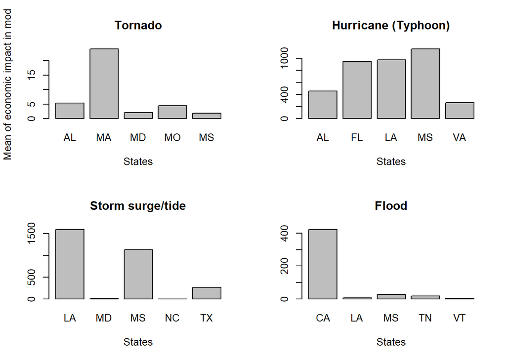

```r
par(mfrow = c(2,2))
barplot(mean_total~STATE, data = tornado_mon[1:5,], xlab = "States", ylab = "Mean of economic impact in mod", main = "Tornado")
barplot(mean_total~STATE, data = hurricane_mon[1:5,], xlab = "States", ylab = "", main = "Hurricane (Typhoon)")
barplot(mean_total~STATE, data = storm_mon[1:5,], xlab = "States", ylab = "", main = "Storm surge/tide")
barplot(mean_total~STATE, data = flood_mon[1:5,], xlab = "States", ylab = "", main = "Flood")
```

At last, we study the population impact

```r
tornado_pop <- stormdata %>%  filter(stormdata$EVTYPE == "TORNADO")  %>%
            group_by(STATE) %>%
            summarise(mean_fat = mean(FATALITIES), mean_inj = mean(INJURIES)) %>%
            arrange(desc(mean_fat))
tornado_pop[1:10,]
```

```
## # A tibble: 10 x 3
##    STATE mean_fat mean_inj
##    <chr>    <dbl>    <dbl>
##  1 AL      0.318     3.00
##  2 MA      0.316    21.1
##  3 TN      0.310     3.11
##  4 MO      0.290     2.50
##  5 NC      0.101     1.41
##  6 NH      0.0909    0.364
##  7 GA      0.0881    1.25
##  8 IN      0.0845    1.43
##  9 MS      0.0803    1.02
## 10 AR      0.0746    0.911
```

```r
heat_pop <- stormdata %>%  filter(stormdata$EVTYPE == "EXCESSIVE HEAT")  %>%
            group_by(STATE) %>%
            summarise(mean_fat = mean(FATALITIES), mean_inj = mean(INJURIES)) %>%
            arrange(desc(mean_fat))
heat_pop[1:10,]
```

```
## # A tibble: 10 x 3
##    STATE mean_fat mean_inj
##    <chr>    <dbl>    <dbl>
##  1 NY        3.53   0.0588
##  2 AZ        3.44   0
##  3 PA        2.7    0.9
##  4 TX        1.83   0.167
##  5 IL        1.60   0.909
##  6 CA        1.30   1.67
##  7 NV        1.3    0
##  8 MD        1.21   0
##  9 TN        1      0.0526
## 10 UT        1      0
```

```r
ff_pop <- stormdata %>%  filter(stormdata$EVTYPE == "FLASH FLOOD")  %>%
            group_by(STATE) %>%
            summarise(mean_fat = mean(FATALITIES), mean_inj = mean(INJURIES)) %>%
            arrange(desc(mean_fat))
ff_pop[1:10,]
```

```
## # A tibble: 10 x 3
##    STATE mean_fat mean_inj
##    <chr>    <dbl>    <dbl>
##  1 AS      0.154   0.231
##  2 GU      0.143   0
##  3 HI      0.0535  0.0160
##  4 DE      0.05    0.0375
##  5 AZ      0.0473  0.0243
##  6 NH      0.0448  0.0597
##  7 PR      0.0391  0.00135
##  8 WY      0.032   0.048
##  9 WA      0.0308  0.0308
## 10 AR      0.0272  0.0213
```

```r
rc_pop <- stormdata %>%  filter(stormdata$EVTYPE == "RIP CURRENT")  %>%
            group_by(STATE) %>%
            summarise(mean_fat = mean(FATALITIES), mean_inj = mean(INJURIES)) %>%
            arrange(desc(mean_fat))
rc_pop[1:10,]
```

```
## # A tibble: 10 x 3
##    STATE mean_fat mean_inj
##    <chr>    <dbl>    <dbl>
##  1 CT        2       0
##  2 PR        2       0
##  3 IN        1.43    0.571
##  4 NY        1.3     0.3
##  5 TX        1.24    0.353
##  6 SC        1.06    0.235
##  7 AL        1       0.1
##  8 IL        1       0
##  9 LA        1       1
## 10 MD        1       1
```

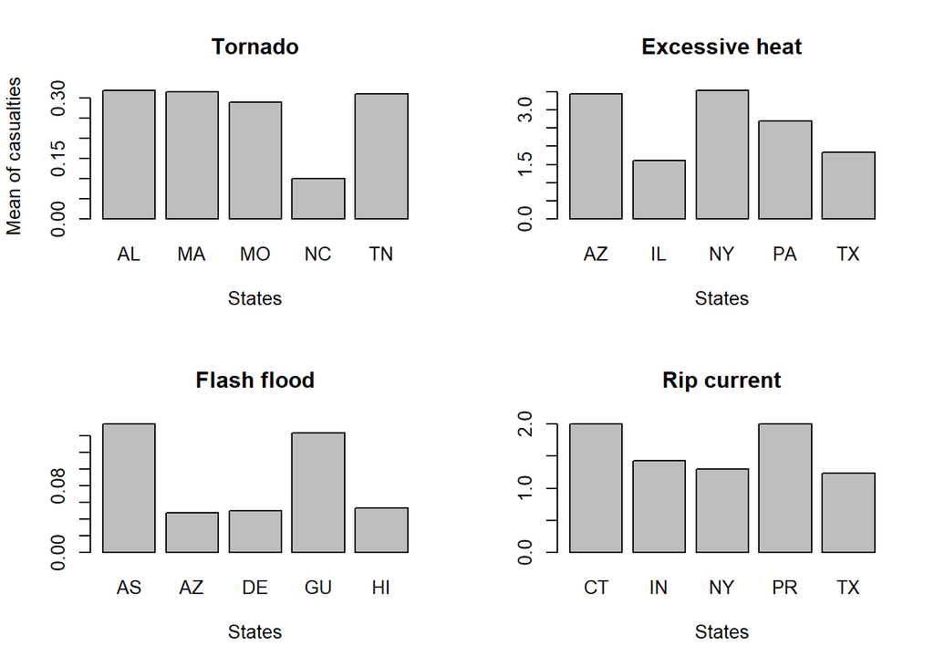

```r
par(mfrow = c(2,2))
barplot(mean_fat~STATE, data = tornado_pop[1:5,], xlab = "States", ylab = "Mean of casualties", main = "Tornado")
barplot(mean_fat~STATE, data = heat_pop[1:5,], xlab = "States", ylab = "", main = "Excessive heat")
barplot(mean_fat~STATE, data = ff_pop[1:5,], xlab = "States", ylab = "", main = "Flash flood")
barplot(mean_fat~STATE, data = rc_pop[1:5,], xlab = "States", ylab = "", main = "Rip current")
```

## Conclusion

From this analysis, we conclude that the weather events that have the major economic impact in proportion are tornadoes, hurricanes, storms, and floods and Mississippi is the most affected state, since is affected by this four events. On the other hand, the events that affect the most to the population are tornadoes, excessive heat, flash floods and rip currents and New York and Texas are affected by two of this events.